# Global Library Imports

```
Missing Value Summary:
                            Missing Count  Missing Percentage Data Type
Injury_Prognosis                      146            2.983245     Int64
SpecialJourneyExpenses                136            2.778913   float64
SpecialLoanerVehicle                  130            2.656314   float64
GeneralUplift                         126            2.574581   float64
SpecialAdditionalInjury               126            2.574581   float64
SpecialTherapy                        126            2.574581   float64
Whiplash                              123            2.513282    object
Vehicle Type                          122            2.492848    object
SpecialUsageLoss                      121            2.472415   float64
GeneralRest                           119            2.431549   float64
Vehicle Age                           118            2.411116   float64
SpecialHealthExpenses                 117            2.390682   float64
Number of Passengers                  115            2.349816   float64
SpecialEarningsLoss                   114            2.329383   float64
GeneralFixed                          114            2.329383   float64
SpecialFixes                          112            2.288517   float64
AccidentType                          111            2.268083    object
Accident Description                  111            2.268083    object
Weather Conditions                    110            2.247650    object
SpecialOverage                        109            2.227217   float64
Injury Description                    109            2.227217    object
SpecialTripCosts                      108            2.206784   float64
Minor_Psychological_Injury            107            2.186351    object
Dominant injury                       103            2.104618    object
SpecialAssetDamage                    102            2.084185   float64
Exceptional_Circumstances              97            1.982019    object
```

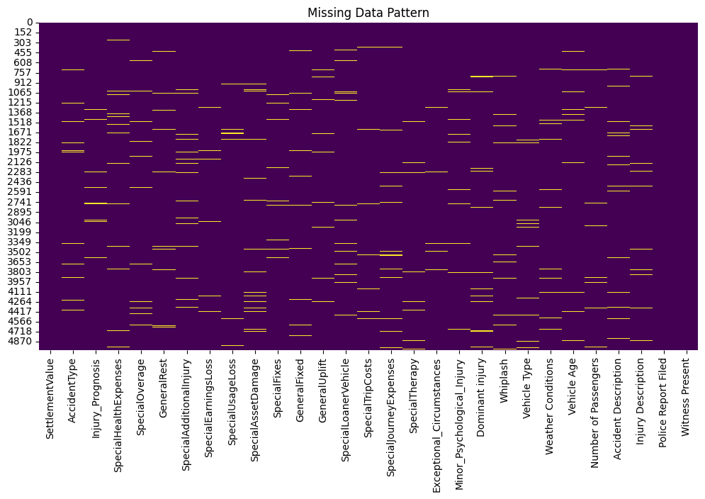

```
Total number of rows with missing values: 1288
```

[output not shown]

[output cut: 25 more lines]

[output not shown]

```python
# 1. Analyze Missing Data Patterns
missing_summary = pd.DataFrame({
    'Missing Count': df.isnull().sum(),
    'Missing Percentage': df.isnull().mean()*100,
    'Data Type': df.dtypes
}).sort_values('Missing Percentage', ascending=False)

print("Missing Value Summary:")
print(missing_summary[missing_summary['Missing Count'] > 0])

# Visualize missing data pattern
plt.figure(figsize=(12,6))
sns.heatmap(df.isnull(), cbar=False, cmap='viridis')
plt.title("Missing Data Pattern")
plt.show()

# display total count of all rows having at least one missing value
print("Total number of rows with missing values: " + str(df.isnull().any(axis=1).sum()))


# 2. Evaluate Feature Importance
# Use your mutual information scores and VIF analysis
important_features = ['Injury_Prognosis', 'GeneralFixed', 'SpecialTherapy','Exceptional_Circumstances','Whiplash']

# 3. Create Imputation Strategies
def create_imputation_pipelines():
    strategies = {
        'drop_rows': SimpleImputer(strategy='constant', fill_value='DROP_ROW'),
        'mean_impute': SimpleImputer(strategy='mean'),
        'iterative_impute': IterativeImputer(random_state=42),
        'zero_impute': SimpleImputer(strategy='constant', fill_value=0)
    }
    return strategies

# 4. Preprocessing Pipeline
def preprocess_data(df, strategy):

    # Handle missing values based on feature importance
    for col in df.columns:
        if col in important_features and df[col].isnull().any():
            if strategy == 'drop_rows':
                df = df[df[col].notna()]
            else:
                if col in BINARY_COLUMNS:
                    df = binary_encode(df, col, 'Yes')
                imputer = create_imputation_pipelines()[strategy]
                df[col] = imputer.fit_transform(df[[col]]).ravel()

    # Handle remaining missing values
    for col in df.select_dtypes(include='number').columns:
        if df[col].isnull().any():
            imputer = SimpleImputer(strategy='zero')
            df[col] = imputer.fit_transform(df[[col]]).ravel()
    for col in df.select_dtypes(include='object').columns:
        if df[col].isnull().any():
            imputer = SimpleImputer(strategy='most_frequent')
            df[col] = imputer.fit_transform(df[[col]]).ravel()
        if col in BINARY_COLUMNS:
            df = binary_encode(df, col, 'Yes')
        if col in CATEGORY_COLUMNS:
            df = one_hot_encode(df, col)

    print("Total number of rows with missing values: " + str(df.isnull().any(axis=1).sum()))
    print(df.info())
    return df

# 5. Test Different Approaches
# X = df.drop('SettlementValue', axis=1)
# y = df['SettlementValue']
# X_train, X_test, y_train, y_test = train_test_split(X, y, test_size=0.2, random_state=42)

results = {}
for strategy in ['drop_rows', 'mean_impute', 'iterative_impute', 'zero_impute']:
    # Preprocess
    # X_train_processed = preprocess_data(X_train.copy(), strategy)

    df_processed = preprocess_data(df.copy(), strategy)
    X = df_processed.drop('SettlementValue', axis=1)
    y = df_processed['SettlementValue']
    X_train, X_test, y_train, y_test = train_test_split(X, y, test_size=0.2, random_state=42)

    # Filter test set to match training columns if rows were dropped
    # if strategy == 'drop_rows':
    #     X_test_processed = X_test.reindex(X_train_processed.columns, axis=1)
    # else:
    #     X_test_processed = preprocess_data(X_test.copy(), strategy)

    # Model training
    model = make_pipeline(
        RandomForestRegressor(n_estimators=100, random_state=42)
    )

    #model.fit(X_train_processed, y_train)
    model.fit(X_train, y_train)

    # Evaluation
    #preds = model.predict(X_test_processed)
    preds = model.predict(X_test)
    rmse = np.sqrt(mean_squared_error(y_test, preds))
    results[strategy] = rmse

# Compare results
print("\nModel Performance Comparison:")
print(pd.DataFrame.from_dict(results, orient='index', columns=['RMSE']))
```

# Dataset Initial Exploration

## Display Dataset Summary Info

```python
ml_dataset.info()
```

```
<class 'pandas.core.frame.DataFrame'>
RangeIndex: 5000 entries, 0 to 4999
Data columns (total 36 columns):
 #   Column                      Non-Null Count  Dtype
---  ------                      --------------  -----
 0   SettlementValue             4894 non-null   float64
 1   AccidentType                4878 non-null   object
 2   Injury_Prognosis            4844 non-null   object
 3   SpecialHealthExpenses       4870 non-null   float64
 4   SpecialReduction            4879 non-null   float64
 5   SpecialOverage              4883 non-null   float64
 6   GeneralRest                 4872 non-null   float64
 7   SpecialAdditionalInjury     4866 non-null   float64
 8   SpecialEarningsLoss         4872 non-null   float64
 9   SpecialUsageLoss            4870 non-null   float64
```

[output cut: 28 more lines]

All numeric columns are float64 type. All string columns are Object type.

There are null values in multiple columns, these will need to be handled appropriately. Discussion with the client has identified that null values in the settlement column indicate unsettled claims, so these should not be used in model training.

## Removal of unsettled claims entries

```python
# remove rows where the settlement column is null
ml_dataset = ml_dataset.dropna(subset=['SettlementValue'])
```

```python
ml_dataset = extract_int_from_string(ml_dataset,'Injury_Prognosis')
```

## Display Column Value Ranges

```python
# display summary statistics for numerical columns
ml_dataset.describe()
```

|  | SettlementValue | Injury_Prognosis | SpecialHealthExpenses | SpecialReduction | SpecialOverage | GeneralRest | SpecialAdditionalInjury | SpecialEarningsLoss | SpecialUsageLoss | SpecialMedications | ... | SpecialFixes | GeneralFixed | GeneralUplift | SpecialLoanerVehicle | SpecialTripCosts | SpecialJourneyExpenses | SpecialTherapy | Vehicle Age | Driver Age | Number of Passengers |
| --- | --- | --- | --- | --- | --- | --- | --- | --- | --- | --- | --- | --- | --- | --- | --- | --- | --- | --- | --- | --- | --- |
| count | 4894.000000 | 4748.0 | 4777.000000 | 4781.0 | 4785.000000 | 4775.000000 | 4768.000000 | 4780.000000 | 4773.000000 | 4767.000000 | ... | 4782.000000 | 4780.000000 | 4768.000000 | 4764.000000 | 4786.000000 | 4758.000000 | 4768.000000 | 4776.000000 | 4776.000000 | 4779.000000 |
| mean | 1218.010685 | 6.105518 | 3.682018 | 0.0 | 13.470086 | 462.605569 | 0.278922 | 51.429741 | 9.122145 | 0.112068 | ... | 3.185705 | 687.285565 | 10.452076 | 7.849840 | 1.951890 | 11.735666 | 184.580357 | 9.507956 | 48.792714 | 2.482737 |
| std | 858.866309 | 2.753099 | 85.870386 | 0.0 | 84.760462 | 766.942861 | 13.101063 | 392.065706 | 65.947574 | 1.404761 | ... | 102.311077 | 399.701043 | 50.363289 | 142.570855 | 13.052007 | 49.417960 | 224.298369 | 5.730669 | 17.817638 | 1.109656 |
| min | 240.000000 | 1.0 | 0.000000 | 0.0 | 0.000000 | 0.000000 | 0.000000 | 0.000000 | 0.000000 | 0.000000 | ... | 0.000000 | 240.000000 | 0.000000 | 0.000000 | 0.000000 | 0.000000 | 0.000000 | 0.000000 | 18.000000 | 1.000000 |
| 25% | 669.140000 | 5.0 | 0.000000 | 0.0 | 0.000000 | 0.000000 | 0.000000 | 0.000000 | 0.000000 | 0.000000 | ... | 0.000000 | 495.000000 | 0.000000 | 0.000000 | 0.000000 | 0.000000 | 0.000000 | 4.000000 | 33.000000 | 1.000000 |
| 50% | 988.000000 | 6.0 | 0.000000 | 0.0 | 0.000000 | 0.000000 | 0.000000 | 0.000000 | 0.000000 | 0.000000 | ... | 0.000000 | 520.000000 | 0.000000 | 0.000000 | 0.000000 | 0.000000 | 56.850000 | 10.000000 | 49.000000 | 2.000000 |
| 75% | 1510.000000 | 8.0 | 0.000000 | 0.0 | 0.000000 | 903.000000 | 0.000000 | 0.000000 | 0.000000 | 0.000000 | ... | 0.000000 | 895.000000 | 0.000000 | 0.000000 | 0.000000 | 0.000000 | 350.000000 | 14.000000 | 64.000000 | 3.000000 |
| max | 7862.900000 | 24.0 | 3024.000000 | 0.0 | 1250.000000 | 3912.640000 | 889.000000 | 7735.580000 | 1050.000000 | 30.250000 | ... | 4000.000000 | 4345.000000 | 1430.000000 | 4408.160000 | 254.200000 | 880.000000 | 1225.000000 | 19.000000 | 79.000000 | 4.000000 |

8 rows × 22 columns

## Show total values for each numerical column

```python
# for each numerical column, diplay the count of non-zero values
print("column - count of non-zero - sum of values - mean values (excluding zero rows)")
for column in ml_dataset.select_dtypes(include='float64'):
    print(column + " - " + str(ml_dataset[ml_dataset[column] != 0][column].count()) + " - " + str(ml_dataset[column].sum()) + " - " + str((ml_dataset[column].sum() / ml_dataset[ml_dataset[column] != 0][column].count())))
```

```
column - count of non-zero - sum of values - mean values (excluding zero rows)
SettlementValue - 4894 - 5960944.29 - 1218.010684511647
SpecialHealthExpenses - 16 - 17589.0 - 1099.3125
SpecialReduction - 0 - 0.0 - nan
SpecialOverage - 157 - 64454.36 - 410.5373248407643
GeneralRest - 1633 - 2208941.59 - 1352.6892774035516
SpecialAdditionalInjury - 8 - 1329.9 - 166.2375
SpecialEarningsLoss - 289 - 245834.16 - 850.63723183391
SpecialUsageLoss - 237 - 43540.0 - 183.71308016877637
SpecialMedications - 38 - 534.23 - 14.058684210526316
SpecialAssetDamage - 461 - 160725.5 - 348.6453362255965
SpecialRehabilitation - 5 - 96.19999999999999 - 19.24
SpecialFixes - 9 - 15234.04 - 1692.6711111111113
GeneralFixed - 4780 - 3285225.0 - 687.2855648535565
GeneralUplift - 306 - 49835.5 - 162.86111111111111
SpecialLoanerVehicle - 67 - 37396.64 - 558.1588059701493
SpecialTripCosts - 252 - 9341.747500000001 - 37.07042658730159
SpecialJourneyExpenses - 987 - 55838.3 - 56.57375886524823
SpecialTherapy - 2664 - 880079.14 - 330.36003753753755
Vehicle Age - 4552 - 45410.0 - 9.975834797891038
Driver Age - 4776 - 233034.0 - 48.79271356783919
Number of Passengers - 4779 - 11865.0 - 2.482736974262398
```

Looking at the values above, SpecialReduction can be ignored as there are no non-zero values.

SpecialRehabilitation can be ignored as it appears infrequently and contributes little to overall settlement amount (max value £21).

SpecialMedication can be ignored as it appears infrequently and contributes little to overall settlement amount (max value £30).

Accident Date and Claim date are not relevant to the claim outcome

Columns with a high maximum value but low mean are candidates for grouping and further analysis is required.

SpecialAdditionalInjury, SpecialFixes, SpecialHealthExpenses and SpecialLoanerVehicle could all be relevant groups, as they have low frequency but can be high value.

GeneralUplift - there are a small number of high values in this column

SpecialTripCosts and SpecialJourneyExpenses may be important - need to perform further analysis

Recommend investigating the relationship and correlations between the different types of columns (eg. can medical / trip+journey expenses be grouped)

## Removal of Columns

Along with the numerical columns identified above, Gender and age values should be dropped as they are protected characteristics and should not be used for training models due to the possibility of introducing bias into the model.

```python
ml_dataset = ml_dataset.drop(columns=['SpecialReduction','SpecialRehabilitation','SpecialMedications','Driver Age','Gender','Accident Date','Claim Date','Vehicle Age','Number of Passengers'])
```

```python
for column in ml_dataset.select_dtypes(include='float64'):
    print(f"'{column}',")
```

```
'SettlementValue',
'SpecialHealthExpenses',
'SpecialOverage',
'GeneralRest',
'SpecialAdditionalInjury',
'SpecialEarningsLoss',
'SpecialUsageLoss',
'SpecialAssetDamage',
'SpecialFixes',
'GeneralFixed',
'GeneralUplift',
'SpecialLoanerVehicle',
'SpecialTripCosts',
'SpecialJourneyExpenses',
'SpecialTherapy',
```

## Display the first x rows of the dataset using a slider widget

```python
widgets.interact(lambda x: ml_dataset.head(x), x=(widgets.IntSlider(min=5, max=50, step=5, value=5)))
```

```
interactive(children=(IntSlider(value=5, description='x', max=50, min=5, step=5), Output()), _dom_classes=('wi…
```

```
<function __main__.<lambda>(x)>
```

```python
from sklearn import preprocessing
df_norm = ml_dataset.copy()
scaler = preprocessing.MinMaxScaler()
df_norm[NUMERIC_COLUMNS] = scaler.fit_transform(df_norm[NUMERIC_COLUMNS])
df_norm.head()
```

|  | SettlementValue | AccidentType | Injury_Prognosis | SpecialHealthExpenses | SpecialOverage | GeneralRest | SpecialAdditionalInjury | SpecialEarningsLoss | SpecialUsageLoss | SpecialAssetDamage | ... | Exceptional_Circumstances | Minor_Psychological_Injury | Dominant injury | Whiplash | Vehicle Type | Weather Conditions | Accident Description | Injury Description | Police Report Filed | Witness Present |
| --- | --- | --- | --- | --- | --- | --- | --- | --- | --- | --- | --- | --- | --- | --- | --- | --- | --- | --- | --- | --- | --- |
| 0 | 520.0 | Rear end | 5 | 0.0 | 0.0 | 0.000000 | 0.0 | 0.0 | 0.000000 | 0.0 | ... | No | Yes | Arms | Yes | Motorcycle | Rainy | Side collision at an intersection. | Whiplash and minor bruises. | Yes | Yes |
| 1 | 870.0 | Rear end | 2 | 0.0 | 0.0 | 0.132903 | 0.0 | 0.0 | 0.085714 | 0.0 | ... | No | Yes | Multiple | Yes | Motorcycle | Snowy | Side collision at an intersection. | Minor cuts and scrapes. | Yes | Yes |
| 2 | 2140.0 | Other side pulled out of side road | 7 | 0.0 | 0.0 | 0.357815 | 0.0 | 0.0 | 0.000000 | 0.0 | ... | No | No | Legs | Yes | Motorcycle | Sunny | Lost control on a snowy road. | Whiplash and minor bruises. | Yes | No |
| 3 | 520.0 | Rear end - Clt pushed into next vehicle | 4 | 0.0 | 0.0 | 0.000000 | 0.0 | 0.0 | 0.000000 | 0.0 | ... | No | Yes | Arms | Yes | Truck | Rainy | Side collision at an intersection. | Minor cuts and scrapes. | Yes | Yes |
| 4 | 260.0 | Rear end | 3 | 0.0 | 0.0 | 0.000000 | 0.0 | 0.0 | 0.000000 | 0.0 | ... | No | Yes | Arms | No | Motorcycle | Rainy | Lost control on a snowy road. | Concussion and bruised ribs. | Yes | Yes |

5 rows × 27 columns

```python
df_norm = df.copy()
df_norm = df_norm.drop(columns=NUMERIC_COLUMNS)
# df_norm = df_norm.drop(columns=TARGET_COLUMN)


# for column in ml_dataset:
#     column = ml_dataset[column]
#     # Get the count of negatives in column
#     count = (column < 0).sum()
#     print('Count of negative values in column ', column.name, ' is : ', count)

for col in df_norm.columns:
    if df_norm[col].isnull().any():
        imputer = SimpleImputer(strategy='most_frequent')
        df_norm[col] = imputer.fit_transform(df_norm[[col]]).ravel()
    if col in BINARY_COLUMNS:
        df_norm = binary_encode(df_norm, col, 'Yes')
    # if col in CATEGORY_COLUMNS:
    #     df_norm = one_hot_encode(df_norm, col)

# for col in df_norm.columns:
#     if col in CATEGORY_COLUMNS:
#         df_norm = df_norm.drop(columns=[col])
#     else:
#         if df_norm[col].isnull().any():
#             imputer = SimpleImputer(strategy='most_frequent')
#             df_norm[col] = imputer.fit_transform(df_norm[[col]]).ravel()
#         df_norm = binary_encode(df_norm, col, 'Yes')


df_norm.info()
```

[output not shown]

```python
df_norm.head()
```

|  | SettlementValue | AccidentType | Injury_Prognosis | Exceptional_Circumstances | Minor_Psychological_Injury | Dominant injury | Whiplash | Vehicle Type | Weather Conditions | Vehicle Age | Number of Passengers | Accident Description | Injury Description | Police Report Filed | Witness Present |
| --- | --- | --- | --- | --- | --- | --- | --- | --- | --- | --- | --- | --- | --- | --- | --- |
| 0 | 520.0 | Rear end | 5.0 | No | Yes | Arms | Yes | Motorcycle | Rainy | 13.0 | 4.0 | Side collision at an intersection. | Whiplash and minor bruises. | Yes | Yes |
| 1 | 870.0 | Rear end | 2.0 | No | Yes | Multiple | Yes | Motorcycle | Snowy | 4.0 | 2.0 | Side collision at an intersection. | Minor cuts and scrapes. | Yes | Yes |
| 2 | 2140.0 | Other side pulled out of side road | 7.0 | No | No | Legs | Yes | Motorcycle | Sunny | 9.0 | 4.0 | Lost control on a snowy road. | Whiplash and minor bruises. | Yes | No |
| 3 | 520.0 | Rear end - Clt pushed into next vehicle | 4.0 | No | Yes | Arms | Yes | Truck | Rainy | 5.0 | 1.0 | Side collision at an intersection. | Minor cuts and scrapes. | Yes | Yes |
| 4 | 260.0 | Rear end | 3.0 | No | Yes | Arms | No | Motorcycle | Rainy | 9.0 | 1.0 | Lost control on a snowy road. | Concussion and bruised ribs. | Yes | Yes |

```python
# from kmodes.kmodes import KModes
from kmodes.kprototypes import KPrototypes

# kmodes = KModes(n_clusters=3, init='Huang')
kproto = KPrototypes(n_clusters=5, init='Huang')
clusters = kproto.fit_predict(df_norm, categorical=[1,5,7,8,11,12])
# clusters = kmodes.fit_predict(df_norm)
# #join data with labels
labels = pd.DataFrame(clusters)
labeledClaims = pd.concat((df_norm,labels),axis=1)
labeledClaims = labeledClaims.rename({0:'labels'},axis=1)
labeledClaims.head()
```

[output not shown]

```python
from ipywidgets import interact

# Function to create scatter plot
def scatterplot(x, y):
    plt.figure(figsize=(8, 6))
    sns.scatterplot(data=df_norm, x=x, y=y)
    plt.title(f'{x} vs {y}')
    plt.show()

# Create interactive widget
interact(scatterplot,
         x=df_norm.columns.tolist(),
         y=df_norm.columns.tolist())

# widgets.interact(lambda x: ml_dataset.head(x), x=(widgets.IntSlider(min=5, max=50, step=5, value=5)))
```

```
interactive(children=(Dropdown(description='x', options=('SettlementValue', 'AccidentType', 'Injury_Prognosis'…
```

```
<function __main__.scatterplot(x, y)>
```

```python
# display count of values in each label
labeledClaims['labels'].value_counts()
```

[output not shown]

## Outlier Detection

### The following section is retained for reference only, as applying outlier removal to the dataset ultimately reduced performance of the trained model. Code relating to inspecting the outliers has been left intact, but all code relating to removal of outlier data has been commented out to prevent it from impacting model training.

Outlier detection is useful to remove datapoints that may disproportionately affect the model training

### Extreme Value Analysis

Calculate the interquartile range (IQR)

IQR (Inter quantiles range)= 75th quantile — 25th quantile

An outlier will be in the following upper and lower boundaries:

- Upper Boundary = 75th quantile +(IQR * 1.5)
- Lower Boundary = 25th quantile — (IQR * 1.5)

Or for extreme cases:

- Upper Boundary = 75th quantile +(IQR * 3)
- Lower Boundary = 25th quantile — (IQR * 3)

If the data point is above the upper boundary or below the lower boundary, it can be considered as an outlier.

```python
# function to calculate inter-quartile ranges for a given column
def calc_iqr(column):
    temp_df = pd.DataFrame(ml_dataset[column])

    # calculate inter-quartile range
    IQR = (temp_df.quantile(0.75) - temp_df.quantile(0.25)).round(3)

    # Calculate lower limit and lower limit extreme
    lower_limit = (temp_df.quantile(0.25) - (IQR * 1.5)).round(3)
    lower_limit_extreme = (temp_df.quantile(0.25) - (IQR * 3)).round(3)

    # prevent negative numbers being evaluated
    lower_limit[lower_limit < 0] = 0
    lower_limit_extreme[lower_limit_extreme < 0] = 0

    # get lower boundary and lower boundary extreme from the dataframe
    compare_lower = lower_limit.iloc[0]
    compare_lower_ex = lower_limit_extreme.iloc[0]

    # compare the column data with the boundary value
    lower_criteria = temp_df[(temp_df.iloc[:,0]) < compare_lower]
    lower_ex_criteria = temp_df[(temp_df.iloc[:,0]) < compare_lower_ex]

    # Calculate upper limit and upper limit extreme
    upper_limit = (temp_df.quantile(0.75) + (IQR * 1.5)).round(3)
    upper_limit_extreme = (temp_df.quantile(0.75) + (IQR * 3)).round(3)

    # get upper boundary and upper boundary extreme from the dataframe
    compare_upper = upper_limit.iloc[0]
    compare_upper_ex = upper_limit_extreme.iloc[0]

    # compare the column data with the boundary value
    upper_criteria = temp_df[(temp_df.iloc[:,0]) > compare_upper]
    upper_ex_criteria = temp_df[(temp_df.iloc[:,0]) > compare_upper_ex]

    # display results of the calculations
    print('\nTotal Claims:',temp_df.size)
    print(column, 'Inter-Quartile Range (IQR) = ', IQR[0])

    print('\n', column, 'Lower Limit = ', lower_limit[0])
    print('Claims with', column, 'below Lower Limit:', lower_criteria.size)

    print('\n', column, 'Lower Limit Extreme = ', lower_limit_extreme[0])
    print('Claims with', column, 'below Lower Limit Extreme:', lower_ex_criteria.size)

    print('\n', column, 'Upper Limit = ', upper_limit[0])
    print('Claims with', column, 'above Upper Limit:', upper_criteria.size)

    print('\n', column, 'Upper Limit Extreme = ', upper_limit_extreme[0])
    print('Claims with', column, 'above Upper Limit Extreme:', upper_ex_criteria.size)
```

```python
# widget to display IQR values for the column selected in a drop-down box
widgets.interact(lambda column: calc_iqr(column), column=NUMERIC_COLUMNS)
```

```
interactive(children=(Dropdown(description='column', options=('SpecialHealthExpenses', 'SpecialOverage', 'Gene…
```

```
<function __main__.<lambda>(column)>
```

### Removal of Extreme Outliers

Remove extreme outliers identified in the previous section

*The following code section is commented out to prevent data removal*

```python
# ml_dataset_ex_outs = ml_dataset

# index = ml_dataset[(ml_dataset['SkinThickness'] > 53)].index
# ml_dataset_ex_outs.drop(index, inplace=True)

# index = ml_dataset[(ml_dataset['BMI'] > 63.90)].index
# ml_dataset_ex_outs.drop(index, inplace=True)

# index = ml_dataset[(ml_dataset['DiabetesPedigreeFunction'] > 1.77375)].index
# ml_dataset_ex_outs.drop(index, inplace=True)
```

### Visualizing Outliers

Using a box plot is a quick method of visualizing outliers

```python
# # sns.boxplot(y='annual_inc', data = data)
# widgets.interact(lambda X: sns.boxplot(data=ml_dataset, x=X), X=['Pregnancies','Glucose','BloodPressure','SkinThickness','BMI','DiabetesPedigreeFunction','Age'])
```

### List Outliers Based on Limits Identifed in the Boxplot

```python
# print(ml_dataset[(ml_dataset['SkinThickness'] > 80)].index)
# print(ml_dataset[(ml_dataset['Age'] > 65)].index)
# print(ml_dataset[(ml_dataset['BMI'] > 50)].index)
# print(ml_dataset[(ml_dataset['BloodPressure'] > 105)].index)
# print(ml_dataset[(ml_dataset['BloodPressure'] < 40)].index)
# print(ml_dataset[(ml_dataset['Pregnancies'] > 13)].index)
```

### Outlier Removal Based on Boxplot

*This section is commented out to prevent data removal*

```python
# index = ml_dataset[(ml_dataset['SkinThickness'] > 80)].index
# ml_dataset.drop(index, inplace=True)

# index = ml_dataset[(ml_dataset['Age'] > 65)].index
# ml_dataset.drop(index, inplace=True)

# index = ml_dataset[(ml_dataset['BMI'] > 50)].index
# ml_dataset.drop(index, inplace=True)

# index = ml_dataset[(ml_dataset['BloodPressure'] > 105)].index
# ml_dataset.drop(index, inplace=True)

# index = ml_dataset[(ml_dataset['BloodPressure'] < 40)].index
# ml_dataset.drop(index, inplace=True)

# index = ml_dataset[(ml_dataset['Pregnancies'] > 13)].index
# ml_dataset.drop(index, inplace=True)
```

# Initial Visualizations

## Outcome Distribution

```python
# sns.countplot(x=ml_dataset['Settlement'])
```

## Histogram chart

Histogram chart using dropdown widget to allow switching between x values. This allows quick viewing of the recorded frequency of the dataset feature values.

```python
# widgets.interact(lambda X: ml_dataset[X].plot.hist(bins=10, figsize=(10,5)), X=['Age','Pregnancies','Glucose','BloodPressure','SkinThickness','BMI','DiabetesPedigreeFunction'])
```

## Distribution Plot Chart

Distribution Plot chart using dropdown widget to allow switching between x values. This allows comparison of the feature distributions for each outcome.

```python
# widgets.interact(lambda X: sns.displot(data=ml_dataset, x=X, col='Outcome', kind='kde'), X=['Age','Pregnancies','Glucose','BloodPressure','SkinThickness','BMI','DiabetesPedigreeFunction'])
```

## Scatter Plot Chart

Scatter Plot chart, using X-axis and Y-axis dropdown widgets to allow bivariate analysis for identifying potential relationships between features.

```python
# widgets.interact(lambda X, Y: sns.scatterplot(data=ml_dataset, style=ml_dataset['Outcome'], hue=ml_dataset['Outcome'], x=X, y=Y), X=['Age','Pregnancies','Glucose','BloodPressure','SkinThickness','BMI','DiabetesPedigreeFunction'], Y=['Glucose','Pregnancies','BloodPressure','SkinThickness','BMI','DiabetesPedigreeFunction','Age'])
```

## Correlation Matrix

A correlation matrix quantifies and visualizes the linear relationships between variables, aiding in feature selection and understanding variable interactions.

```python
# # calculate the feature correlation values
# c = ml_dataset.select_dtypes('number').corr().round(3)

# # Plot the correlation matrix as a heatmap
# import matplotlib.pyplot as plt
# import seaborn as sns
# sns.heatmap(c, annot=True)
# plt.show()
```

# Recursive Feature Elimination

```python
# # import required library functions
# from sklearn.feature_selection import RFECV
# from sklearn.linear_model import LinearRegression

# # split dataset to features and classifications
# X = ml_dataset.drop(["Outcome"], axis = 1)
# y = ml_dataset["Outcome"]

# # use a linear regressino model for cross validation testing
# regressor = LinearRegression()
# feature_selector = RFECV(regressor)

# # train the model
# fit = feature_selector.fit(X,y)

# # determine and print result of feature evaluation
# optimal_feature_count = feature_selector.n_features_
# print(f"Optimal numer of features: {optimal_feature_count}")

# print(X.columns)
# print(feature_selector.ranking_)
# print(feature_selector.support_)

# # plot chart of evaluation runs
# plt.plot(range(1, len(fit.grid_scores_) + 1), fit.grid_scores_, marker = "o")
# plt.ylabel("Model Score")
# plt.xlabel("Number of Features")
# plt.title(f"Feature Selection using RFE")
# plt.tight_layout()
# plt.show()
```

### Removal of features recommended by the RFECV process.

```python
# # drop specificed columns to a new dataframe
# ml_dataset_4col = ml_dataset.drop(['BloodPressure', 'SkinThickness','Age'], axis=1)
```

# Data Preparation

## Show unique values for each text field

```python
def display_text_values(col):
    print(col.name, 'Unique values:', col.unique())
```

```python
for column in ml_dataset.select_dtypes(include='object'):
    display_text_values(ml_dataset[column])
```

```
AccidentType Unique values: ['Rear end' 'Other side pulled out of side road'
 'Rear end - Clt pushed into next vehicle'
 'Other side pulled on to roundabout' nan
 "Other side reversed into Clt's vehicle"
 "Other side changed lanes and collided with clt's vehicle" 'Other'
 "Other side turned across Clt's path"
 'Other side drove on wrong side of the road'
 "Other side changed lanes on a roundabout colliding with clt's vehicle"
 'Rear end - 3 car - Clt at front'
 "Other side reversed into clt's stationary vehicle"
 "Other side collided with Clt's parked vehicle"
 "Other side pulled from parked position into the path of clt's vehicle"
 "Other side opened their door, hitting clt's vehicle"
 'Other side overtook and hit Clt when pulling in'
 'Other side overtook and pulled in too soon'
 'Other side overtook whilst clt was turning right']
Exceptional_Circumstances Unique values: ['No' 'Yes' nan]
Minor_Psychological_Injury Unique values: ['Yes' 'No' nan]
Dominant injury Unique values: ['Arms' 'Multiple' 'Legs' 'Hips' nan]
Whiplash Unique values: ['Yes' 'No' nan]
Vehicle Type Unique values: ['Motorcycle' 'Truck' 'Car' nan]
Weather Conditions Unique values: ['Rainy' 'Snowy' 'Sunny' nan]
Accident Description Unique values: ['Side collision at an intersection.' 'Lost control on a snowy road.'
 'Hit a deer on the highway.' 'Swerved to avoid another vehicle.'
 'Rear-ended at a stoplight.' nan]
Injury Description Unique values: ['Whiplash and minor bruises.' 'Minor cuts and scrapes.'
 'Concussion and bruised ribs.' 'Fractured arm and leg.'
 'Sprained ankle and wrist.' nan]
Police Report Filed Unique values: ['Yes' 'No']
Witness Present Unique values: ['Yes' 'No']
```

The InjuryPrognosis column should be converted to an integer value representing number of months

Exceptional_Circumstances, Minor_Psychological_Injury, Whiplash, Police Report Filed, Witness Present should be converted to binary value using one-hot, however handling of any null values must be addressed first. Most likely conclusion is that a blank field is treated as a no, however the claim entry form should use a drop down allowing only Yes or No, with a default value of No to prevent missing data in future records. Likewise for other input fields (weather, vehicle, injury type) these should offer a drop down selection menu, but be blank by default and input validation should prevent record creation without a value being entered.

Accident Date and Claim Date are unlikely to be relevant to the claim details, however the difference between these dates may be indicative of claim success due to difficulty in proving fault retrospectively. As such, a new column could be created showing the time elapsed between these dates.

Unless there are significant correlations to the settlement outcomes, retaining Injury description and dominant injury type is probably not needed, will perform analysis to determine which can be dropped. Likewise for accident type and accident description.

## Convert prognosis to integer

Prognosis is likely to be an important factor in determining the outcome. Initilly considered dropping the rows with NaN for prognosis, however some of the claims with NaN prognosis resulted in large payouts, so it may be important to keep the data. I suspect that once the remaining categorical data has been properly encoded or removed, then it will be possible to use a KNN imputer to fill in the prognosis column null values

```python
# Extract numbers and convert to nullable integer type
# ml_dataset['Injury_Prognosis'] = (
#     ml_dataset['Injury_Prognosis']
#     .str.extract('(\d+)', expand=False)
#     .astype('Int64')
# )

ml_dataset = extract_int_from_string(ml_dataset, 'Injury_Prognosis')
print(ml_dataset['Injury_Prognosis'].head(20))
```

[output not shown]

## Check for Duplicate Rows

Duplicate rows contaminate the data and could skew the training process, negatively impacting prediction performance.

```python
# calculate duplicates
duplicates = ml_dataset.duplicated()
# report duplicates
print(duplicates.any())
# list duplicate rows
print(ml_dataset[duplicates])
```

```
True
      SettlementValue                             AccidentType  \
4394           2280.0  Rear end - Clt pushed into next vehicle
4426            520.0                                 Rear end

      Injury_Prognosis  SpecialHealthExpenses  SpecialOverage  GeneralRest  \
4394                10                    0.0             0.0       2300.0
4426                 5                    0.0             0.0          0.0

      SpecialAdditionalInjury  SpecialEarningsLoss  SpecialUsageLoss  \
4394                      0.0                  0.0               0.0
4426                      0.0                  0.0               0.0

      SpecialAssetDamage  ...  Exceptional_Circumstances  \
4394                 0.0  ...                         No
4426                 0.0  ...                         No

      Minor_Psychological_Injury  Dominant injury  Whiplash  Vehicle Type  \
4394                         Yes         Multiple       Yes           Car
4426                         Yes             Arms        No         Truck

      Weather Conditions                Accident Description  \
4394               Rainy  Side collision at an intersection.
4426               Snowy  Side collision at an intersection.

          Injury Description Police Report Filed Witness Present
4394  Fractured arm and leg.                 Yes              No
4426  Fractured arm and leg.                  No              No

[2 rows x 27 columns]
```

## Check for Negative Values

Negative values where they are not expected/possible would also affect the reliability of the analysis and should be removed prior to proceeding

```python
# Check for negative values in all columns of Dataframe
for column in ml_dataset.select_dtypes(include='float64'):
    column = ml_dataset[column]
    # Get the count of negatives in column
    count = (column < 0).sum()
    print('Count of negative values in column ', column.name, ' is : ', count)
```

```
Count of negative values in column  SettlementValue  is :  0
Count of negative values in column  SpecialHealthExpenses  is :  0
Count of negative values in column  SpecialOverage  is :  0
Count of negative values in column  GeneralRest  is :  0
Count of negative values in column  SpecialAdditionalInjury  is :  0
Count of negative values in column  SpecialEarningsLoss  is :  0
Count of negative values in column  SpecialUsageLoss  is :  0
Count of negative values in column  SpecialAssetDamage  is :  0
Count of negative values in column  SpecialFixes  is :  0
Count of negative values in column  GeneralFixed  is :  0
Count of negative values in column  GeneralUplift  is :  0
Count of negative values in column  SpecialLoanerVehicle  is :  0
Count of negative values in column  SpecialTripCosts  is :  0
Count of negative values in column  SpecialJourneyExpenses  is :  0
Count of negative values in column  SpecialTherapy  is :  0
```

*No negative values exist*

## Convert numerical values to integers

Numerical columns are primarily money amounts so can be rounded to whole pounds - prediction amount does not require accuracy in pence

It doesn't make sense to have number of passengers as float

Age of car also does not need to be accurate to fractions of a year

```python
# for column in ml_dataset.select_dtypes(include='float64'):
#     ml_dataset[column] = ml_dataset[column].round()
#     ml_dataset[column] = ml_dataset[column].astype('Int64')

ml_dataset = float_columns_to_int(ml_dataset)
```

```python
ml_dataset.head(20)
```

|  | SettlementValue | AccidentType | Injury_Prognosis | SpecialHealthExpenses | SpecialOverage | GeneralRest | SpecialAdditionalInjury | SpecialEarningsLoss | SpecialUsageLoss | SpecialAssetDamage | ... | Exceptional_Circumstances | Minor_Psychological_Injury | Dominant injury | Whiplash | Vehicle Type | Weather Conditions | Accident Description | Injury Description | Police Report Filed | Witness Present |
| --- | --- | --- | --- | --- | --- | --- | --- | --- | --- | --- | --- | --- | --- | --- | --- | --- | --- | --- | --- | --- | --- |
| 0 | 520 | Rear end | 5 | 0 | 0 | 0 | 0 | 0 | 0 | 0 | ... | No | Yes | Arms | Yes | Motorcycle | Rainy | Side collision at an intersection. | Whiplash and minor bruises. | Yes | Yes |
| 1 | 870 | Rear end | 2 | 0 | 0 | 520 | 0 | 0 | 90 | 0 | ... | No | Yes | Multiple | Yes | Motorcycle | Snowy | Side collision at an intersection. | Minor cuts and scrapes. | Yes | Yes |
| 2 | 2140 | Other side pulled out of side road | 7 | 0 | 0 | 1400 | 0 | 0 | 0 | 0 | ... | No | No | Legs | Yes | Motorcycle | Sunny | Lost control on a snowy road. | Whiplash and minor bruises. | Yes | No |
| 3 | 520 | Rear end - Clt pushed into next vehicle | 4 | 0 | 0 | 0 | 0 | 0 | 0 | 0 | ... | No | Yes | Arms | Yes | Truck | Rainy | Side collision at an intersection. | Minor cuts and scrapes. | Yes | Yes |
| 4 | 260 | Rear end | 3 | 0 | 0 | 0 | 0 | 0 | 0 | 0 | ... | No | Yes | Arms | No | Motorcycle | Rainy | Lost control on a snowy road. | Concussion and bruised ribs. | Yes | Yes |
| 5 | 520 | Rear end | 6 | 0 | 0 | 0 | 0 | 0 | 0 | 0 | ... | No | Yes | Multiple | Yes | Car | Rainy | Lost control on a snowy road. | Minor cuts and scrapes. | Yes | No |
| 6 | 1015 | Rear end | <NA> | 0 | 0 | 0 | 0 | 0 | 0 | 9 | ... | No | Yes | Legs | Yes | Motorcycle | Sunny | Hit a deer on the highway. | Whiplash and minor bruises. | No | No |
| 7 | 1032 | Other side pulled out of side road | 8 | 0 | 0 | 0 | 0 | 0 | 0 | 0 | ... | No | No | Legs | Yes | Car | Sunny | Side collision at an intersection. | Concussion and bruised ribs. | No | Yes |
| 8 | 808 | Rear end | 6 | 0 | 0 | 0 | 0 | 0 | 0 | 0 | ... | No | Yes | Arms | No | Motorcycle | Snowy | Swerved to avoid another vehicle. | Minor cuts and scrapes. | Yes | Yes |
| 9 | 500 | Rear end | 2 | 0 | 0 | 0 | 0 | 0 | 0 | 0 | ... | No | Yes | Hips | Yes | Motorcycle | Rainy | Rear-ended at a stoplight. | Minor cuts and scrapes. | Yes | Yes |
| 10 | 836 | Other side pulled on to roundabout | 6 | 0 | 0 | 0 | 0 | <NA> | 0 | 0 | ... | No | Yes | Arms | Yes | Car | Sunny | Swerved to avoid another vehicle. | Concussion and bruised ribs. | No | No |
| 11 | 645 | Rear end | 6 | 0 | 0 | 0 | 0 | 0 | 0 | 0 | ... | Yes | No | Arms | No | Motorcycle | Rainy | Side collision at an intersection. | Fractured arm and leg. | Yes | Yes |
| 12 | 1167 | Rear end | 7 | 0 | 0 | 0 | 0 | 0 | 0 | 0 | ... | Yes | No | Arms | No | Motorcycle | Rainy | Swerved to avoid another vehicle. | Whiplash and minor bruises. | Yes | No |
| 13 | 1144 | Rear end | 5 | 0 | 0 | 1558 | 0 | 0 | 0 | 0 | ... | No | Yes | Arms | Yes | Motorcycle | Snowy | Side collision at an intersection. | Fractured arm and leg. | No | No |
| 14 | 1665 | Rear end | 9 | 0 | 0 | 770 | 0 | 0 | 0 | 0 | ... | No | Yes | Multiple | Yes | Truck | Sunny | Side collision at an intersection. | Concussion and bruised ribs. | No | No |
| 15 | 1969 | Other side pulled out of side road | 9 | 0 | 0 | 520 | 0 | 0 | 0 | 0 | ... | No | Yes | Legs | Yes | Car | Sunny | Swerved to avoid another vehicle. | Concussion and bruised ribs. | Yes | Yes |
| 16 | 1425 | Rear end | 5 | 0 | 0 | 1050 | 0 | 0 | 0 | 0 | ... | No | Yes | Multiple | Yes | Motorcycle | Rainy | Lost control on a snowy road. | Sprained ankle and wrist. | Yes | No |
| 17 | 728 | Rear end | 5 | 0 | 0 | 0 | 0 | 173 | 0 | 60 | ... | No | No | Multiple | Yes | Car | Rainy | Hit a deer on the highway. | Sprained ankle and wrist. | Yes | No |
| 18 | 945 | Rear end | 7 | 0 | 0 | 0 | 0 | 0 | 0 | 0 | ... | No | Yes | Multiple | No | Car | Snowy | Hit a deer on the highway. | Concussion and bruised ribs. | Yes | No |
| 19 | 865 | NaN | 4 | 0 | 0 | 0 | 0 | 0 | 0 | 0 | ... | No | No | Arms | No | Car | Snowy | Hit a deer on the highway. | Sprained ankle and wrist. | Yes | Yes |

20 rows × 27 columns

## Check for mutual information between categorical string columns and settlement value and injury prognosis

```python
# use mutual_info_regression to calculate the mutual information between the target column and each feature column
min_max_scaler = MinMaxScaler()

def check_mutual_info(df, target_col, feature_col):
    temp_df = df[[target_col, feature_col]]
    temp_df = temp_df.dropna()

    count = 0
    mutual_info = mutual_info_regression(temp_df[[feature_col]], temp_df[target_col])
    if mutual_info > 0.05:
        print(f'Mutual Information between {target_col} and {feature_col}: {mutual_info}')
        count += 1
    else:
        pass
        ## print(f'Mutual Information between {target_col} and {feature_col} not statistically significant: {mutual_info}')
    return count
```

```python
mi_df = ml_dataset.copy()
mi_df = mi_df.drop(DROP_COLUMNS, axis=1)
mi_df = mi_df.drop(NUMERIC_COLUMNS, axis=1)
mi_df = mi_df.dropna(subset=['SettlementValue','Injury_Prognosis','Exceptional_Circumstances','Whiplash'])
mi_df = zero_fill_num_columns(mi_df)
mi_df = fill_category_columns(mi_df)
mi_df = extract_int_from_string(mi_df,'Injury_Prognosis')
mi_df = binary_encode(mi_df,BINARY_COLUMNS,'Yes')
mi_df.info()
```

[output not shown]

```python
cat_cols = ['Dominant injury','Vehicle Type','Weather Conditions','Injury Description',
            'Accident Description','AccidentType','Exceptional_Circumstances',
            'Minor_Psychological_Injury','Whiplash','Police Report Filed','Witness Present']
for col in cat_cols:
    temp_df = mi_df[['SettlementValue','Injury_Prognosis',col]]
    # temp_df = mi_df[['SettlementValue','Injury_Prognosis',col]]
    # one hot encode the categorical column
    temp_df = pd.get_dummies(temp_df, columns=[col])
    temp_df = temp_df.dropna()
    # normalize the numerical columns
    min_max_scaler = MinMaxScaler()
    temp_df[['SettlementValue','Injury_Prognosis']] = min_max_scaler.fit_transform(temp_df[['SettlementValue','Injury_Prognosis']])
    # print('temp_df for col:', col)
    # print(temp_df.head())
    # display correlation matrix for temp_df
    count = 0
    # print('Mutual Info Calculations for categorical column:', col)
    for cat_col in temp_df.columns:
        if cat_col != 'SettlementValue' and cat_col != 'Injury_Prognosis':
            count += check_mutual_info(temp_df, 'SettlementValue', cat_col)
            count += check_mutual_info(temp_df, 'Injury_Prognosis', cat_col)
    #display(temp_df.corr())
    if count == 0:
        print('No Mutual Information found for column:', col)
    # check_correlation(temp_df, 'SettlementValue', col)
    # check_correlation(temp_df, 'Injury_Prognosis', col)
```

```
No Mutual Information found for column: Dominant injury
No Mutual Information found for column: Vehicle Type
No Mutual Information found for column: Weather Conditions
No Mutual Information found for column: Injury Description
No Mutual Information found for column: Accident Description
Mutual Information between SettlementValue and AccidentType_Other: [0.07976347]
Mutual Information between SettlementValue and AccidentType_Other side changed lanes and collided with clt's vehicle: [0.05604034]
Mutual Information between SettlementValue and AccidentType_Other side pulled out of side road: [0.1098389]
Mutual Information between SettlementValue and AccidentType_Other side turned across Clt's path: [0.07815321]
Mutual Information between SettlementValue and AccidentType_Rear end: [0.22328921]
Mutual Information between SettlementValue and AccidentType_Rear end - Clt pushed into next vehicle: [0.06168776]
Mutual Information between SettlementValue and Exceptional_Circumstances_No: [0.10671763]
Mutual Information between SettlementValue and Exceptional_Circumstances_Yes: [0.12180003]
Mutual Information between SettlementValue and Minor_Psychological_Injury_No: [0.27419326]
Mutual Information between SettlementValue and Minor_Psychological_Injury_Yes: [0.24685558]
No Mutual Information found for column: Whiplash
No Mutual Information found for column: Police Report Filed
No Mutual Information found for column: Witness Present
```

## Remove category columns that are not correlated

```python
ml_dataset = ml_dataset.drop(columns=['Dominant injury','Injury Description','Weather Conditions','Vehicle Type','Accident Description'])
```